# Introducion

# Decision Tree

```r
frm1<-(Delay~Season+Weather+manufacturer+aircraft_type+engine_type+Age+Dest+Distance)
```

Now using the formula frm1 we are going to construct a decision tree. This model is useful in terms of visualization and ease of understanding. Also, the model provides rules which can be used to suggest various strategies to decrease delays. So , lets create it.

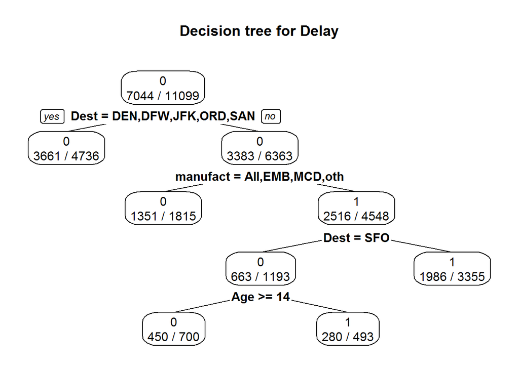

```r
library(rpart)
library(rpart.plot)
fit=rpart(frm1,  data=Train,  method="class")
prp(fit, extra=2, type=2, main="Decision tree for Delay")
```

To create Tree more attractive with probabilities we should use package rattle.

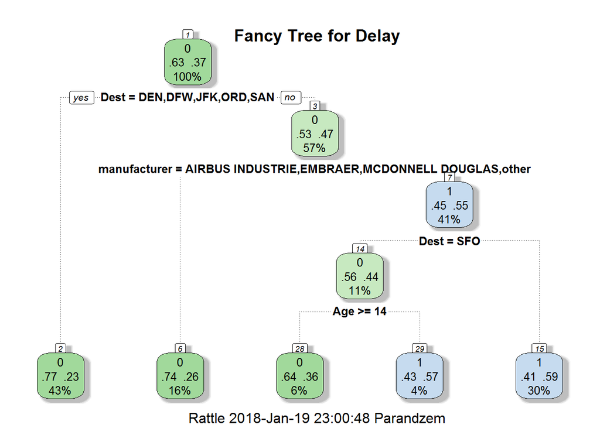

```r
library(rattle)
fancyRpartPlot(fit, main = "Fancy Tree for Delay")
```

These tree shows the same rules but with probabilities. Alo we can use asRules command to see the rules of the tree with probabilites.

```r
asRules(fit)
```

```
##
##  Rule number: 15 [Delay=1 cover=3355 (30%) prob=0.59]
##    Dest=LAS,OAK,PHX,SFO,SJC
##    manufacturer=BOEING,BOMBARDIER INC
##    Dest=LAS,OAK,PHX,SJC
##
##  Rule number: 29 [Delay=1 cover=493 (4%) prob=0.57]
##    Dest=LAS,OAK,PHX,SFO,SJC
##    manufacturer=BOEING,BOMBARDIER INC
##    Dest=SFO
##    Age< 14.5
##
##  Rule number: 28 [Delay=0 cover=700 (6%) prob=0.36]
##    Dest=LAS,OAK,PHX,SFO,SJC
##    manufacturer=BOEING,BOMBARDIER INC
##    Dest=SFO
##    Age>=14.5
##
##  Rule number: 6 [Delay=0 cover=1815 (16%) prob=0.26]
##    Dest=LAS,OAK,PHX,SFO,SJC
##    manufacturer=AIRBUS INDUSTRIE,EMBRAER,MCDONNELL DOUGLAS,other
##
##  Rule number: 2 [Delay=0 cover=4736 (43%) prob=0.23]
##    Dest=DEN,DFW,JFK,ORD,SAN
```

```r
pfit=predict(fit, Test, type="class")
confusionMatrix(pfit, Test$Delay, positive="1")
```

```
## Confusion Matrix and Statistics
##
##           Reference
## Prediction    0    1
##          0 1794  589
##          1  553  762
##
##                Accuracy : 0.6912
##                  95% CI : (0.676, 0.7061)
##     No Information Rate : 0.6347
##     P-Value [Acc > NIR] : 0.0000000000002852
##
##                   Kappa : 0.3303
##  Mcnemar's Test P-Value : 0.3003
##
##             Sensitivity : 0.5640
##             Specificity : 0.7644
##          Pos Pred Value : 0.5795
##          Neg Pred Value : 0.7528
##              Prevalence : 0.3653
##          Detection Rate : 0.2061
##    Detection Prevalence : 0.3556
##       Balanced Accuracy : 0.6642
##
##        'Positive' Class : 1
##
```

The sensitivity is 56% which says if it is given that aircraft will delay our model will predict it with 56% accuracy. Specificity is really high and shows that if it is not delay the model will predict it by 76% accuracy, but as we know the not delayes are majority in our data.

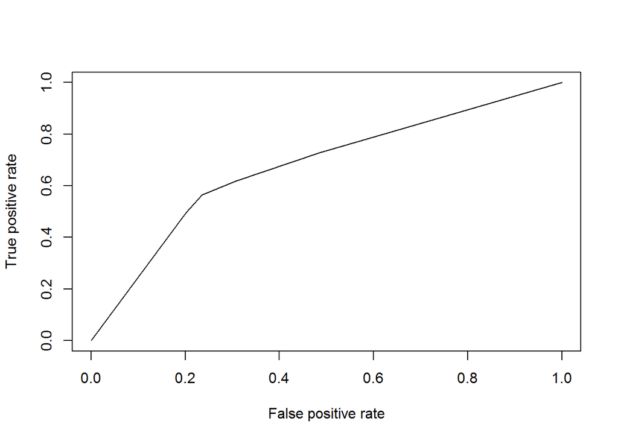

```r
pred_prob=predict(fit, Test, type="prob")

pred = prediction(pred_prob[,2],Test$Delay)
perf_Tree = performance(pred,"tpr","fpr")
plot(perf_Tree)
```

Here is the ROC curve for Decision tree and the area under the curve is equal to 67,5%.

```r
AUC_Tree<-performance(pred, "auc")@y.values
AUC_Tree
```

```
## [[1]]
## [1] 0.6751609
```

Now, to increase accuracy lets create random forest.

```r
set.seed(1)
r_forest<-randomForest(Delay~Season+Weather+manufacturer+aircraft_type+Age+Distance, data=Train,ntree=1000, importance=TRUE, mtry=4,na.action=na.exclude)
```

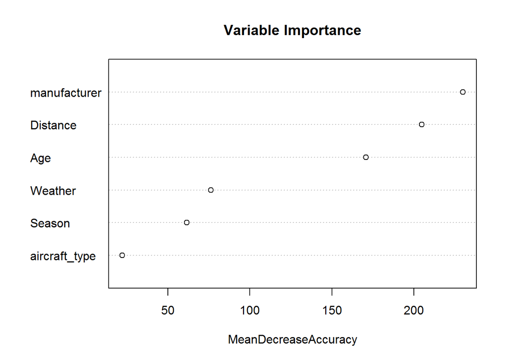

```r
varImpPlot(r_forest, type=1, main="Variable Importance")
```

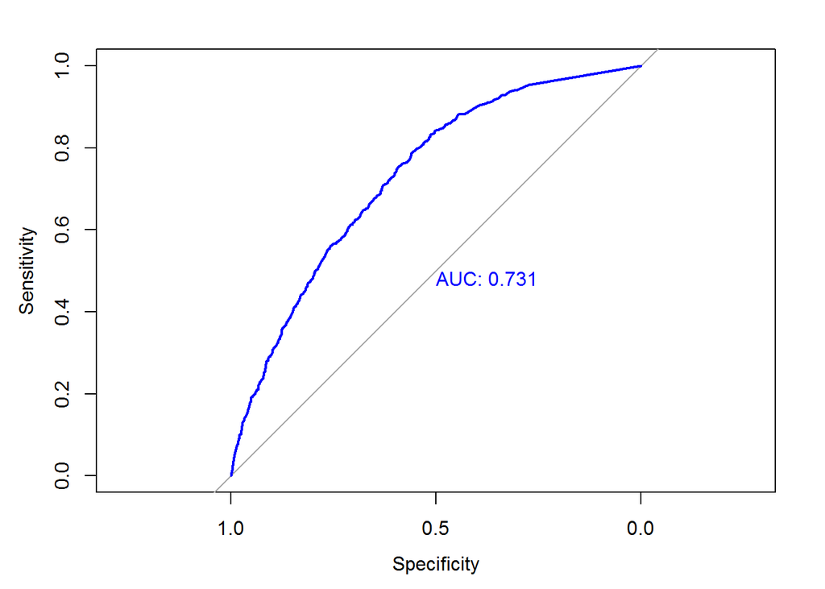

```r
p_forest<-predict(r_forest, newdata=Test, type="prob")
plot(roc(Test$Delay, p_forest[,2]), print.auc = TRUE, col = "blue")
```

As we can see random forest gives higer area under the curve 73% > 67.5%.

```r
set.seed(1700)
rfit=randomForest(Delay~Season+Weather+UniqueCarrier+manufacturer+aircraft_type+engine_type+Age+Dest+Distance,data = Train,na.action=na.exclude)


Forest1<-randomForest(frm1,data=Train,importance = TRUE,ntree = 700,na.action=na.exclude)

pred_f1<-predict(Forest1, newdata=Test)
confusionMatrix(pred_f1, Test$Delay, positive="1")
```

```
## Confusion Matrix and Statistics
##
##           Reference
## Prediction    0    1
##          0 1569  474
##          1  514  781
##
##                Accuracy : 0.704
##                  95% CI : (0.6882, 0.7195)
##     No Information Rate : 0.624
##     P-Value [Acc > NIR] : <0.0000000000000002
##
##                   Kappa : 0.3732
##  Mcnemar's Test P-Value : 0.2147
##
##             Sensitivity : 0.6223
##             Specificity : 0.7532
##          Pos Pred Value : 0.6031
##          Neg Pred Value : 0.7680
##              Prevalence : 0.3760
##          Detection Rate : 0.2340
##    Detection Prevalence : 0.3880
##       Balanced Accuracy : 0.6878
##
##        'Positive' Class : 1
##
```

# KNN

```r
set.seed(1800)

ctrl<-trainControl(method="cv", number=10)

knnFit2 <- train(Delay~Season+Weather+UniqueCarrier+manufacturer+aircraft_type+engine_type+Age+Dest+Distance, data = Train, method = "knn",
                trControl = ctrl,
                preProcess = c("center","scale"),
                tuneGrid=expand.grid(k=5:15),na.action=na.exclude)
```

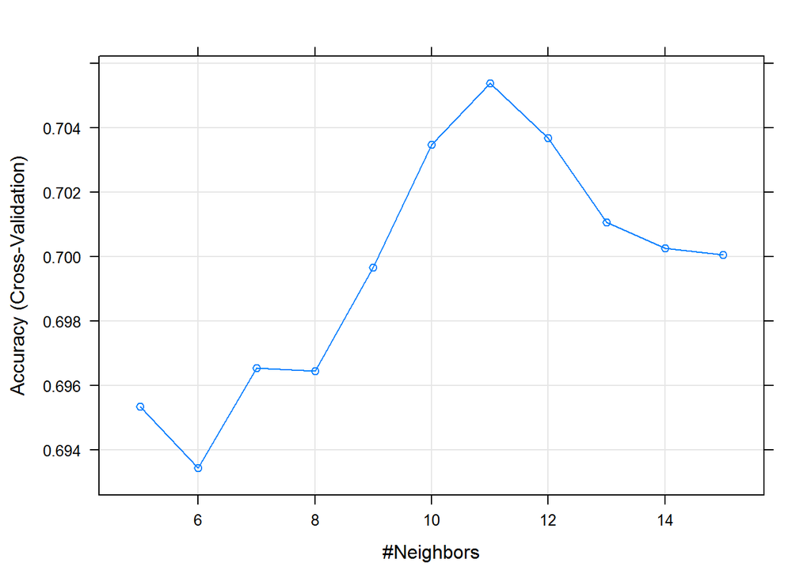

```r
plot(knnFit2)
```

As we can see k=11 has the highest accuracy and is the most appropriate number of the neighbours.

```r
knnFit2
```

```
## k-Nearest Neighbors
##
## 9949 samples
##    9 predictor
##    2 classes: '0', '1'
##
## Pre-processing: centered (42), scaled (42)
## Resampling: Cross-Validated (10 fold)
## Summary of sample sizes: 8953, 8954, 8954, 8955, 8954, 8955, ...
## Resampling results across tuning parameters:
##
##   k   Accuracy   Kappa
##    5  0.6953416  0.3411579
##    6  0.6934335  0.3367273
##    7  0.6965478  0.3433419
##    8  0.6964493  0.3434434
##    9  0.6996640  0.3507986
##   10  0.7034838  0.3592333
##   11  0.7053936  0.3637904
##   12  0.7036869  0.3606055
##   13  0.7010740  0.3549110
##   14  0.7002695  0.3531581
##   15  0.7000677  0.3522584
##
## Accuracy was used to select the optimal model using  the largest value.
## The final value used for the model was k = 11.
```

```r
library(caret)
Test <- Test[complete.cases(Test),]
knn_Predict <- predict(knnFit2, newdata = Test)
confusionMatrix(knn_Predict, Test$Delay, positive="1")
```

```
## Confusion Matrix and Statistics
##
##           Reference
## Prediction    0    1
##          0 1008  365
##          1  291  394
##
##                Accuracy : 0.6812
##                  95% CI : (0.6606, 0.7013)
##     No Information Rate : 0.6312
##     P-Value [Acc > NIR] : 0.000001122
##
##                   Kappa : 0.3012
##  Mcnemar's Test P-Value : 0.00437
##
##             Sensitivity : 0.5191
##             Specificity : 0.7760
##          Pos Pred Value : 0.5752
##          Neg Pred Value : 0.7342
##              Prevalence : 0.3688
##          Detection Rate : 0.1914
##    Detection Prevalence : 0.3328
##       Balanced Accuracy : 0.6475
##
##        'Positive' Class : 1
##
```

Here is the ROC curve.

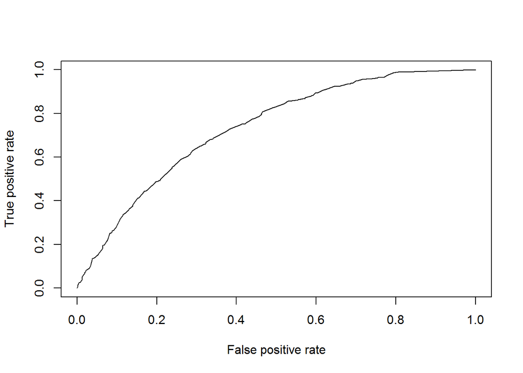

```r
knn_probs<-predict(knnFit2, newdata=Test, type="prob")
P_Test <- prediction(knn_probs[,2], Test$Delay)
perf_knn <- performance(P_Test,"tpr","fpr")
plot(perf_knn)
```

```r
AUC_KNN<-performance(P_Test, "auc")@y.values
AUC_KNN
```

```
## [[1]]
## [1] 0.7335079
```

# Naive Bayes

```r
f<-ftable(data$Delay)
prop.table(f)
```

```
##          0         1
##
##  0.6346557 0.3653443
```

Our goal is to find out the probability of flights being delayed. To get this we devide the number of delayed flights to the number of total flights. In our case 36.5% of flights was delayed and 63.5 was not delayed.

```r
library(e1071)
Bmodel<-naiveBayes(Delay~Season+Weather+UniqueCarrier+manufacturer+aircraft_type+engine_type+Age+Dest+Distance,data=Train, laplace=1)
names(Bmodel)
```

```
## [1] "apriori" "tables"  "levels"  "call"
```

```r
Bmodel$apriori
```

```
## Y
##    0    1
## 7044 4055
```

```r
Bmodel$tables
```

```
## $Season
##    Season
## Y      spring    summer    winter
##   0 0.4611892 0.1559529 0.3828580
##   1 0.4489897 0.1776737 0.3733366
##
## $Weather
##    Weather
## Y       clear       fog      rain
##   0 0.6249468 0.1437491 0.2313041
##   1 0.6574667 0.1599310 0.1826023
##
## $UniqueCarrier
##    UniqueCarrier
## Y            AA          AS          DL          F9          MQ
##   0 0.247023810 0.004393424 0.027777778 0.032454649 0.060799320
##   1 0.110892550 0.001967052 0.004917630 0.021391689 0.019424637
##    UniqueCarrier
## Y            NW          OO          UA          US          WN
##   0 0.003401361 0.094387755 0.228741497 0.031462585 0.200396825
##   1 0.005409393 0.080895009 0.158347676 0.019670519 0.549791001
##    UniqueCarrier
## Y            XE          YV
##   0 0.063208617 0.005952381
##   1 0.025325793 0.001967052
##
## $manufacturer
##    manufacturer
## Y   AIRBUS INDUSTRIE     BOEING BOMBARDIER INC    EMBRAER
##   0       0.08312057 0.49063830     0.03418440 0.16354610
##   1       0.06525486 0.68037429     0.05540507 0.06673233
##    manufacturer
## Y   MCDONNELL DOUGLAS      other
##   0        0.04907801 0.17943262
##   1        0.02782566 0.10440778
##
## $aircraft_type
##    aircraft_type
## Y                     Balloon Fixed Wing Multi-Engine
##   0 0.1000141864 0.0007093205            0.8917576961
```

[output cut: 22 more lines]

```
## $Dest
##    Dest
## Y          DEN        DFW        JFK        LAS        OAK        ORD
##   0 0.11213496 0.07782818 0.12914658 0.10079388 0.06067479 0.10745676
##   1 0.08634686 0.04993850 0.01353014 0.14046740 0.15252153 0.08339483
##    Dest
## Y          PHX        SAN        SFO        SJC
##   0 0.07159059 0.09313864 0.17011625 0.07711936
##   1 0.13234932 0.03247232 0.18228782 0.12669127
##
## $Distance
##    Distance
## Y       [,1]     [,2]
##   0 861.9712 792.2929
##   1 552.0133 497.2662
```

```r
Bmodel$levels
```

```
## [1] "0" "1"
```

```r
Bmodel$call
```

```
## naiveBayes.default(x = X, y = Y, laplace = laplace)
```

Lets construct a confusion matrix

```r
predTest<-predict(Bmodel, newdata=Test)
confusionMatrix(predTest, Test$Delay, positive="1")
```

```
## Confusion Matrix and Statistics
##
##           Reference
## Prediction   0   1
##          0 866 265
##          1 433 494
##
##                Accuracy : 0.6608
##                  95% CI : (0.6399, 0.6813)
##     No Information Rate : 0.6312
##     P-Value [Acc > NIR] : 0.002732
##
##                   Kappa : 0.3036
##  Mcnemar's Test P-Value : 0.0000000002598
##
##             Sensitivity : 0.6509
##             Specificity : 0.6667
##          Pos Pred Value : 0.5329
##          Neg Pred Value : 0.7657
##              Prevalence : 0.3688
##          Detection Rate : 0.2400
##    Detection Prevalence : 0.4504
##       Balanced Accuracy : 0.6588
##
##        'Positive' Class : 1
##
```

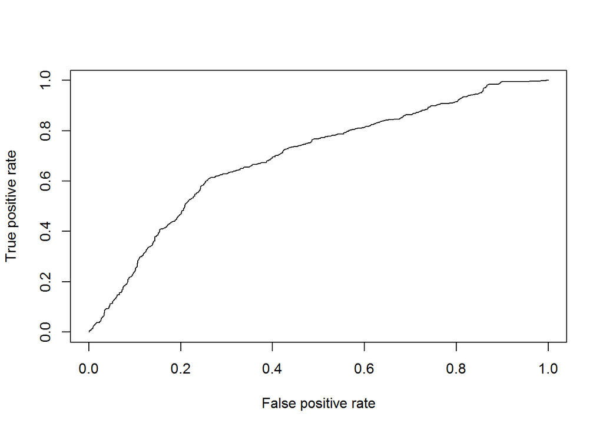

```r
predTestprobab<-predict(Bmodel, newdata=Test,
                        type="raw")
pTest<-prediction(predTestprobab[,2], Test$Delay)
perf_bayes<-performance(pTest, "tpr","fpr")
plot(perf_bayes)
```

Our AUC is 0.69, that is closer to 0.5 than to 1. The accuracy of the model is not that high and the area under the curve of ROC curve is not high, too.

```r
AUC_bayes<-performance(pTest, "auc")@y.values
AUC_bayes
```

```
## [[1]]
## [1] 0.694291
```

# Comparision of ROC Curves

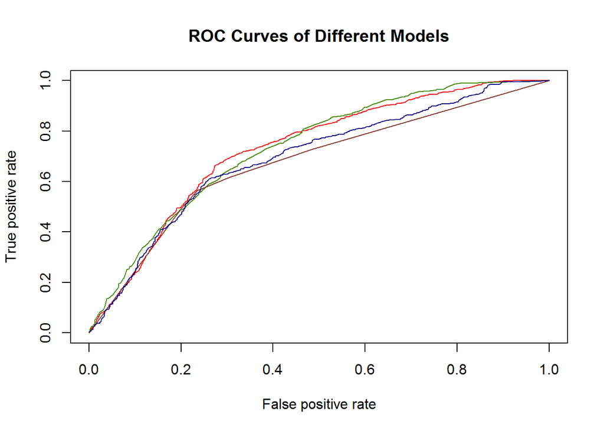

```
## numeric(0)
```

```r
plot(perf_logit,col="red", main="ROC Curves of Different Models")+
plot(perf_knn,col="chartreuse4",add=T)+
plot(perf_Tree,col="coral4",add=T)+
plot(perf_bayes,col="darkblue",add=T)
```

# Comparison of AUC

```r
k<-c(AUC_logit,AUC_Tree,AUC_KNN,AUC_bayes)
k
```

```
## [[1]]
## [1] 0.7295626
##
## [[2]]
## [1] 0.6751609
##
## [[3]]
## [1] 0.7335079
##
## [[4]]
## [1] 0.694291
```

As we can see from the ROC curves and values of AUCs, Logit and KNN have the highest AUC values. However, KNN is not the best model for us as it was mentioned it has low sensitivity and high specificity. To sum up, our final suggestion is to use logit and Tree, as they give opportunity not only to predict Delays quite accuratly but also to see which variables impact delays of the flights and to use that information in further solutions.

# Solutions based on models

According to our data aircraft delays have two types of causes: causes that are attributed to circumstances within the airports control (maintenance, crew scheduling, refueling etc.) and causes which are not connected with the airports’ operations and cannot be controlled and eliminated by the airports (extreme weather), in our case: LAX airport.

On the other hand, we can see that if the aircrafts are fixed wing multi-engine aircrafts (aircraft_typeFixed Wing Multi-Engine) the probability of delay decreases. Thus, LAX should boost the number of flights which aircrafts are fixed wing multi-engine to decrease the probability of delay.

Delays may also be attributed to airline operations procedures. This type of operation is desirable from LAX point of view because it allows the passengers, aircraft and crew to be rerouted to various destinations. The very best companies understand how to move customers through the queue and how to treat them once they get to the front of the line.

No customer likes to wait. Smart businesses strive to minimize not only actual wait time, but also perceived wait time – the amount of time that customers think they waited, regardless of how long they truly waited. Because perceived wait time directly affects customer engagement, it is imperative to manage it in every customer interaction. Here we suggest four strategies that will help the LAX keep its customers’ perceived wait time to a minimum:

1. Appoint a service leader to coordinate customer-employee interactions. Perceived wait time is reduced when an employee greets customers directly, learns the purpose of their visit and then directs them accordingly. These greetings make customers feel as though employees are immediately noticing their needs and beginning the transaction right away – as opposed to customers waiting in line before speaking to an employee.
2. Keep it moving. Customers want to see that all employees are actively working to move customers through queues. Every employee should operate with a sense of urgency and avoid what might easily be perceived as idle conversations or tasks. This reassures customers that employees are striving to help them as quickly as possible. Customers may think that employees are not taking the time to put their needs first.
3. Give customers something to do in line. When customers in line engage in an activity while waiting, their perceived wait time can be reduced. Televisions near lines or waiting areas or magazines lining checkout aisles are classic examples. If customers need to be prepared for their transaction, have employees or signs nearby directing them on what steps to take.
4. Be “FAST.” Even after customers are out of line and at the point of employee interaction, perceived wait time can be diminished. It all depends on the employee-customer interaction: Customers are happier and have lower perceived wait times when employees are “FAST”:

. Friendly to customers

. Accurate during transactions

. Sympathetic to customers’ emotions about waiting

. Thankful for customers’ time and patronage

In other words, to increase satisfaction at the point of service when waits are long, managers of LAX should ensure that employees:

. make things easy and are knowledgeable when assisting customers,

. communicate that customers’ time is valued,

. demonstrate that customers’ business is appreciated by making them top priority when it’s their turn,

. meet every customer need before ending the transaction.